# Resolvendo problema de Negócio

## Entendendo o Problema

Há um aumento na quantidade de entregas pelo APP, e consequentemente um decaimento na avaliação dos clientes. Deseja-se descobrir os motivos do decaimento e sugerir alguma melhoria baseada em dados.

## Conhecendo a base

**Variáveis**

Caractéres

| skim_type | skim_variable | n_missing | complete_rate | character.min | character.max | character.empty | character.n_unique | character.whitespace |
| --- | --- | --- | --- | --- | --- | --- | --- | --- |
| character | TIPO_PAGAMENTO | 0 | 1 | 6 | 13 | 0 | 4 | 0 |
| character | TIPO_ENTREGA | 0 | 1 | 7 | 7 | 0 | 3 | 0 |
| character | ESTADO | 0 | 1 | 2 | 2 | 0 | 5 | 0 |

Fatores

| skim_type | skim_variable | n_missing | complete_rate | factor.ordered | factor.n_unique | factor.top_counts |
| --- | --- | --- | --- | --- | --- | --- |
| factor | CLASSE | 0 | 1 | FALSE | 4 | Bom: 5573, Sem: 4273, Rui: 687, Med: 641 |
| factor | MES | 0 | 1 | TRUE | 10 | Out: 1734, Set: 1731, Jun: 1341, Ago: 1305 |
| factor | DIA | 0 | 1 | TRUE | 7 | Sáb: 3259, Sex: 2342, Dom: 2056, Qui: 1269 |
| factor | TURNO | 0 | 1 | FALSE | 4 | Noi: 5118, Tar: 4460, Man: 1074, Mad: 522 |

Quantitativas

| skim_type | skim_variable | n_missing | complete_rate | numeric.mean | numeric.sd | numeric.p0 | numeric.p25 | numeric.p50 | numeric.p75 | numeric.p100 | numeric.hist |
| --- | --- | --- | --- | --- | --- | --- | --- | --- | --- | --- | --- |
| numeric | ID_PEDIDO | 0 | 1.000000 | 1.884246e+05 | 58540.23929 | 45.0 | 117767.25 | 210567.500 | 233436.000 | 256243.000 | ▁▁▃▂▇ |
| numeric | VALOR_PEDIDO | 0 | 1.000000 | 1.007173e+02 | 397.88371 | 2.2 | 29.88 | 35.904 | 59.488 | 6894.528 | ▇▁▁▁▁ |
| numeric | ID_ENTREGADOR | 0 | 1.000000 | 3.177895e+01 | 14.06820 | 17.0 | 21.00 | 26.000 | 39.000 | 74.000 | ▇▃▂▁▁ |
| numeric | NOTA_ENTREGA | 3897 | 0.651244 | 4.368421e+00 | 1.47981 | -1.0 | 5.00 | 5.000 | 5.000 | 5.000 | ▁▁▁▁▇ |

Data

| skim_type | skim_variable | n_missing | complete_rate | POSIXct.min | POSIXct.max | POSIXct.median | POSIXct.n_unique |
| --- | --- | --- | --- | --- | --- | --- | --- |
| POSIXct | DATA_PEDIDO | 0 | 1 | 2017-01-01 10:11:01 | 2017-10-31 23:42:43 | 2017-07-13 22:01:51 | 11138 |

**Informações**

- Todos os pedidos analisados são de 2017
- As notas de avaliação variam de 1 a 5, sendo -1 os clientes que não responderam e NA os clientes que não receberam a avaliação
- Existe uma classificação de acordo com as notas dos clientes, que seguem as seguintes regras:
  - Ruim: Notas entre 1 e 3
  - Medio: Notas igual a 4
  - Bom: Notas igual a 5
- Houve um atualização no portal de entregas em meados de Junho/Julho
- Houve um investimento em comeciais para a empresa ficar mais conhecida em meados de Julho/Agora

## Primeiras Análises

**Análise do Cenário da empresa**

Agora faremos as primeiras análises da nossa base, expondo o cenário que temos da mesma:

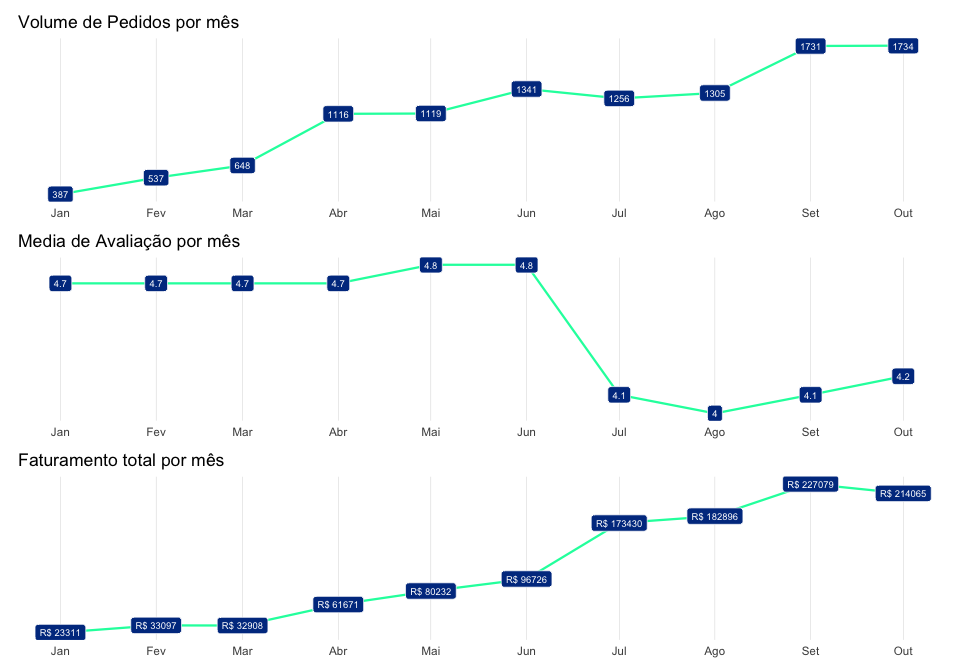

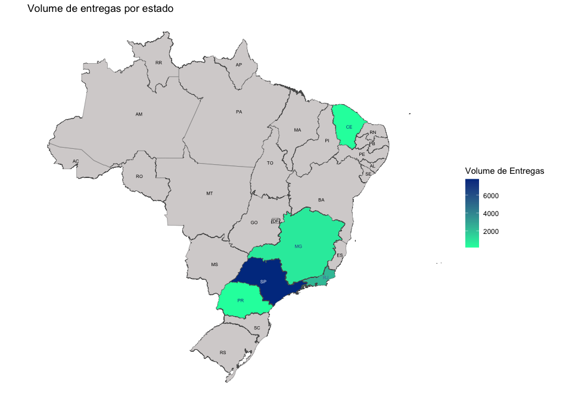

Continuando as análises, vamos agora tratar de de questões de processos de entrega:

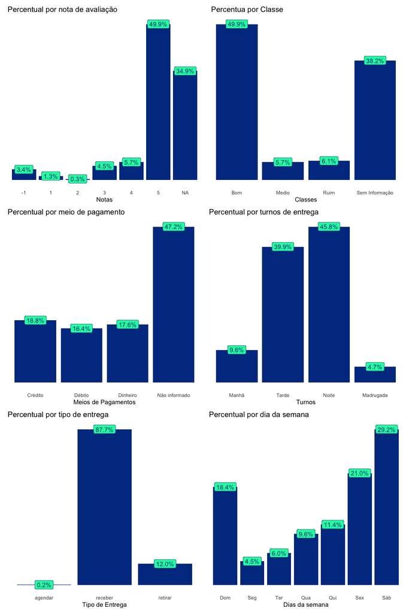

Já conseguimos enxergar alguns ponstos de atençãp no processo de entregas, são estes:

- Existe um percentual muito alto de pedidos que não receberam a avaliação após a entrega do produto
- A maioria dos clientes respondentes classifica a entrega como Boa
- Existe um grande percentual de meios de pagamentos não informados
- Os turnos da tarde e noite são os que possuem maior colune de entreda
- Quase 90% dos clientes recebe o pedido, sendo este o tipo de entrega mais frequente
- Sexta, Sábado e Domingo são os dias de maior volume de entregas

Agora vamos tentar aprofundar nossa análise atacando os pontos levantados anteriormente:

**Os problemas da não informação de avaliação e métodos de pagamento:**

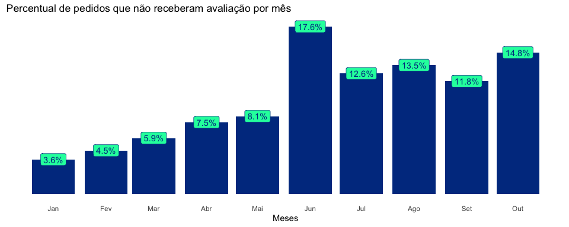

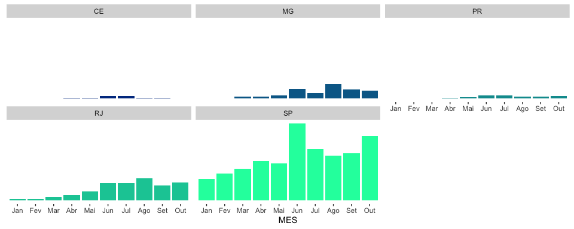

[interactive chart not shown]

Com os gráficos acima pudemos perceber:

- A partir do mês de Junho, onde houve atualização de plataforma, o número de pedidos que não receberam avaliações cresceu
- Os pedidos sem informação de pagamento foram resolvidos em Julho
- Em momento e local de maior quantidade de pedidos, são onde se concentram também os volumes de pedidos sem recebeimento de avaliação, que são os turnos da tarde e noite, nos dias sexta, sábado e domingo e no estado de São Paulo.

**Avaliando os entregadores**

Agora vamos avaliar os indicadores quanto aos entregadores:

Ao todo, nossa base possui 51 entregadores.

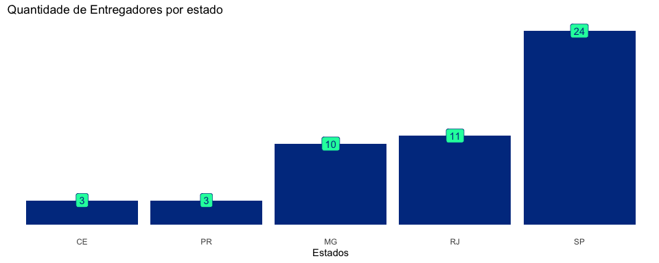

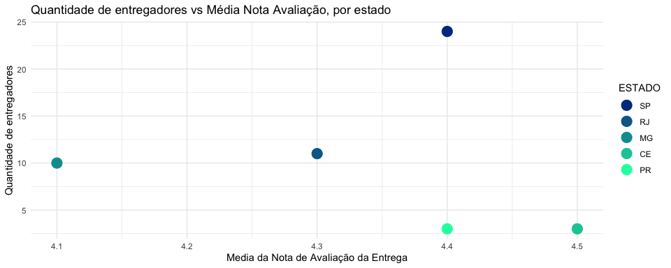

Em relação a quantidade de entregadores por cada estado:

- Não há uma relação evidente quanto entre a quantidade de entregadores e a média de nota de avaliação por estado

Porém, vamo verificar a quantidade de entregadores em relação ao volume de pedidos de cada estado

| ESTADO | Qtd_entregadores | Vol_entregas | media_nota | Media_entregador |
| --- | --- | --- | --- | --- |
| SP | 24 | 7800 | 4.4 | 325.0 |
| RJ | 11 | 2297 | 4.3 | 208.8 |
| MG | 10 | 759 | 4.1 | 75.9 |
| PR | 3 | 164 | 4.4 | 54.7 |
| CE | 3 | 154 | 4.5 | 51.3 |

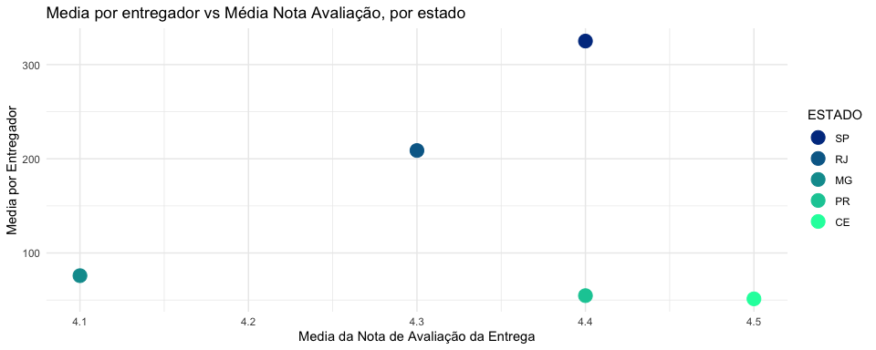